# Agencies from the FBI Crime Data API

Author

Jo Hardin

Published

February 18, 2025

```r
library(tidyverse) # ggplot, lubridate, dplyr, stringr, readr...
library(ggpattern)
library(praise)
```

## The Data

This week we’re exploring data from the [FBI Crime Data API](https://cde.ucr.cjis.gov/LATEST/webapp/#/pages/docApi)! Specifically, we’re looking at agency-level data across all 50 states in the USA. This dataset provides details on law enforcement agencies that have submitted data to the FBI’s Uniform Crime Reporting (UCR) Program and are displayed on the Crime Data Explorer (CDE).

> Currently, the FBI produces four annual publications from data provided by more than 18,000 federal, state, county, city, university and college, and tribal law enforcement agencies voluntarily participating in the UCR program.

> Crime data is dynamic. Offenses occur, arrests are made, and property is recovered every day. The FBI’s Crime Data Explorer, the digital front door for UCR data, is an attempt to reflect that fluidity in crime. The data presented there is updated regularly in a way that UCR publications previously could not be. Launched in 2017, the CDE’s content and features are updated and expanded continuously. CDE enables law enforcement agencies, researchers, journalists, and the public to more easily use and understand the massive amounts of UCR data using charts and graphs.

```r
agencies <- readr::read_csv('https://raw.githubusercontent.com/rfordatascience/tidytuesday/main/data/2025/2025-02-18/agencies.csv')
```

## Plotting agency location.

Code taken (almost) directly from [Steve Ponce.](https://stevenponce.netlify.app/data_visualizations/TidyTuesday/2025/tt_2025_07.html)

### Tidy the data

```r
# Define constants
continental_bounds <- list(
    states_exclude = c("alaska", "hawaii"),
    long = c(-125, -65),
    lat = c(25, 50),
    outlier_thresh = -125
)

# Get continental US map data
continental_states <- map_data("state") |>
    filter(!region %in% continental_bounds$states_exclude)

# Function to check if point is within continental bounds
is_continental <- function(long, lat, bounds) {
    between(long, bounds$long[1], bounds$long[2]) &
        between(lat, bounds$lat[1], bounds$lat[2])
}

# Process agencies data
cleaned_agencies <- agencies |>
    # Initial filtering
    filter(
        !agency_type %in% c(NA, "Unknown", "NA"),
        !state %in% str_to_title(continental_bounds$states_exclude),
        !(agency_type == "Other" & longitude < continental_bounds$outlier_thresh)
    ) |>
    # Filter to continental bounds
    filter(is_continental(longitude, latitude, continental_bounds))

# Calculate agency counts and create labels
agency_counts <- cleaned_agencies |>
    count(agency_type) |>
    arrange(desc(n)) |>
    mutate(
        label = str_glue("{agency_type}\n(n = {format(n, big.mark=',')})"),
        pct_total = n/sum(n) * 100,
        agency_type = factor(agency_type, levels = agency_type)
    )

# Prepare final dataset for plotting
filtered_agencies <- cleaned_agencies |>
    left_join(agency_counts |> select(agency_type, label),
              by = "agency_type") |>
    mutate(
        # Set factor levels based on counts
        agency_type = factor(agency_type,
                             levels = levels(agency_counts$agency_type)),
        # Create labels for faceting
        agency_label = factor(agency_type,
                              levels = levels(agency_type),
                              labels = agency_counts$label)
    )

# Extract total for use in plot
total_agencies <- agency_counts$total_agencies[1]

# Calculate summary statistics
summary_stats <- list(
    total_agencies = sum(agency_counts$n),
    num_categories = n_distinct(filtered_agencies$agency_type),
    city_county_pct = round(100 * sum(agency_counts$n[1:2])/sum(agency_counts$n))
)
```

### Visualize the data

```r
### |-  plot aesthetics ----
# Get base colors with custom palette
colors <-  c(
        "City"                  = "#AD225E",
        "County"                = "#D67195",
        "State Police"          = "#228B7D",
        "Other State Agency"    = "#B8860B",
        "University or College" = "#2D439E",
        "Other"                 = "#8B4513",
        "Tribal"                = "#666666"
    )

### |-  titles and caption ----
title_text <- str_glue("Geographic Distribution of U.S. Law Enforcement Agencies")

subtitle_text <-  str_glue(
    "Showing {format(summary_stats$total_agencies, big.mark=',')} agencies across {summary_stats$num_categories} categories\n",
    "City and County agencies account for {summary_stats$city_county_pct}% of all agencies"
)
```

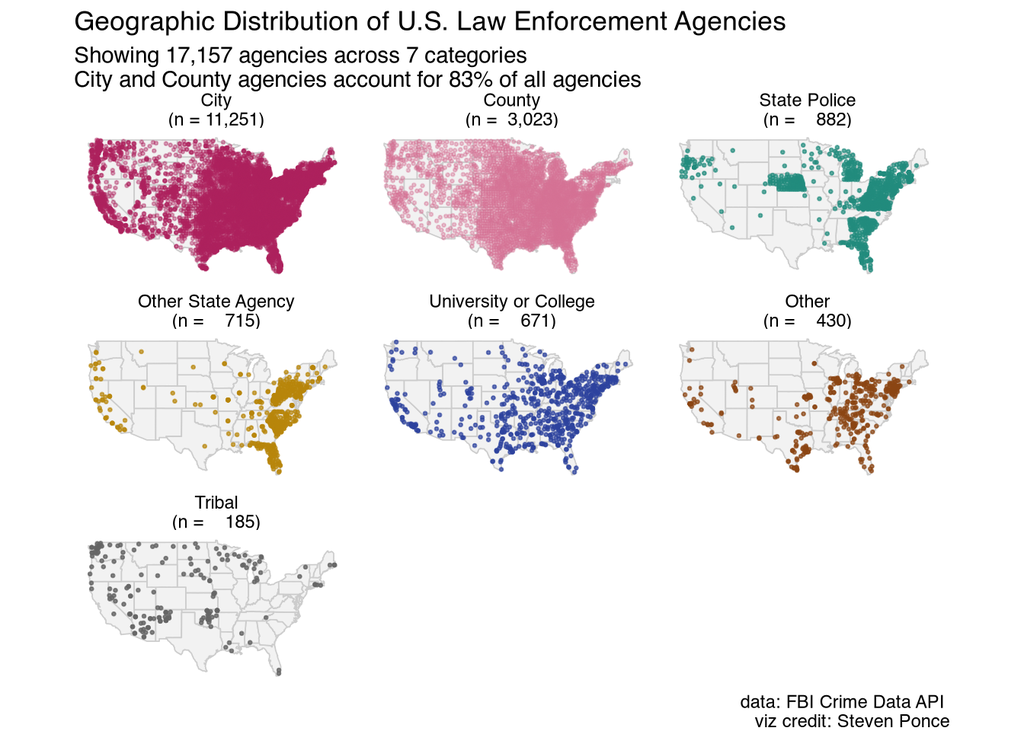

For each of the seven types of FBI agencies, we plot where the agency is located. It is interesting to note the plethora of State Police agencies in Nebraska. Unsurprisingly, many of the Tribal agencies are in the western half of the US. The density of agencies roughly follows US population density.

```r
### |-  Map  ----
p <- ggplot() +
    # Geoms
    geom_polygon(
        data = continental_states,
        aes(x = long, y = lat, group = group),
        fill = "gray95",
        color = "gray80",
        linewidth = 0.3
    ) +
    geom_point(
        data = filtered_agencies,
        aes(x = longitude,
            y = latitude,
            color = agency_type,
            alpha = agency_type),
        size = 0.5
    ) +

    # Scales
    scale_alpha_manual(
        values = c(
            "City" = 0.4,
            "County" = 0.4,
            "Other" = 0.7,
            "Other State Agency" = 0.7,
            "State Police" = 0.7,
            "Tribal" = 0.8,
            "University or College" = 0.7
        ),
        guide = "none"
    ) +
    scale_color_manual(
        values = colors,
        guide = "none"
    ) +
    coord_fixed(
        1.3,
        xlim = continental_bounds$long,
        ylim = continental_bounds$lat
    ) +

    # Labs
    labs(
        x = NULL,
        y = NULL,
        title    = title_text,
        subtitle = subtitle_text,
        caption  = "data: FBI Crime Data API \n viz credit: Steven Ponce",
    ) +

    # Facets
    facet_wrap(
        ~agency_label,
        ncol = 3,
        scales = "fixed"
    ) +
  theme_void()

p
```

```r
praise()
```

```
[1] "You are stellar!"
```